# Models 2 Assignment

Stella Dee

2022-11-19

### Q1: Re-create the conditional boxplot of penguin body mass conditioned on sex and species. Include your boxplot as a figure in your report.

```r
require(palmerpenguins)
```

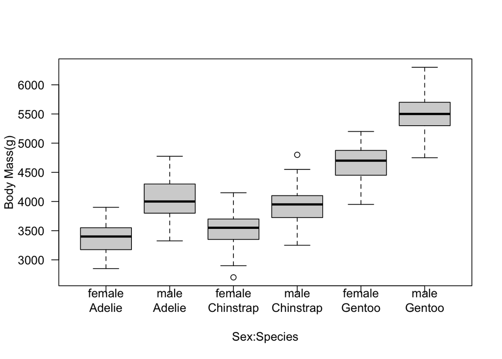

```r
#par(mfrow = c(1,3))
labels= c("female\nAdelie","male\nAdelie","female\nChinstrap","male\nChinstrap","female\nGentoo","male\nGentoo")
boxplot(body_mass_g ~ sex:species, data = penguins, names=labels,ylab= "Body Mass(g)", xlab="Sex:Species", las=1)
```

```r
#boxplot(body_mass_g ~ sex, data = penguins, names=c("female","male"),ylab= "Body Mass(g)", xlab="", las=2)
#boxplot(body_mass_g ~ species, data = penguins, names=c("Adelie","Chinstrap", "Gentoo"),ylab= "Body Mass(g)", xlab="", las=2)
```

### Q2: Based on the boxplots, do you think male penguins are significantly heavier than female penguins of the same species? Explain your reasoning, and be sure to explain why you think any observed differences are significant or not.

Yes, I think the male penguins are significantly heavier than female penguins of the same species for all species. I believe this because the median lines for the male boxplots of all species are outside the entire intraquartile range of the female species boxplots for all species. In fact, the intraquartile range for the male penguins of all species is outside the intraquartile range of the females of all species.

### Q3: Do you think adding sex to a model that already includes species will improve the model fit?

Yes. In the case of all species of penguins, male and female penguins are extremely different–there’s actually no overlap in the intraquartile range when sex and species are both included in the model. Therefore, a model that only uses species will consistently underestimate the body mass of male penguins and overestimate the body of female penguins; adding sex will significantly improve model fit.

### Q4: Show the R-code you used to build fit_both.

```r
fit_both = lm(body_mass_g ~ sex * species, data = penguins)
fit_both
```

```
##
## Call:
## lm(formula = body_mass_g ~ sex * species, data = penguins)
##
## Coefficients:
##              (Intercept)                   sexmale          speciesChinstrap
##                   3368.8                     674.7                     158.4
##            speciesGentoo  sexmale:speciesChinstrap     sexmale:speciesGentoo
##                   1310.9                    -262.9                     130.4
```

### Q5: What is the base case for the two-way model that includes sex and species?

Female Adelie penguins are the base case.

### Q6: What are the names of the two coefficients (from the first column of the coefficient table) that you need to calculate the average mass of female Chinstrap penguins?

(Intercept) and speciesChinstrap

### Q7: What is the predicted average mass of female Chinstrap penguins in the interactive model?

3368.84 + 158.37 = 3527.21g

### Q8: What is the observed average mass of female Chinstrap penguins, calculated from the penguins data?

```r
aggregate(penguins$body_mass_g, by = list(penguins$species, penguins$sex), mean)
```

```
##     Group.1 Group.2        x
## 1    Adelie  female 3368.836
## 2 Chinstrap  female 3527.206
## 3    Gentoo  female 4679.741
## 4    Adelie    male 4043.493
## 5 Chinstrap    male 3938.971
## 6    Gentoo    male 5484.836
```

The observed mass of female Chinstraps is 3527.206g